# report

[figure not shown]

## Projeto Final

**Doconte:**

- Dr. Rafael Santos

**Discente**

- Adriano P. Almeida

## Descrição

Este projeto faz parte do trabalho final da disciplina **CAP-359 - Princípios e Aplicações de Mineração de Dados** que é oferecida no programa de pós graduação em computação aplicada do Instituto Nacional de Pesquisas Espaciais (INPE) e ministrada pelo professor Dr. Rafael Santos. O trabalho tem como objetivo identificar a partir de imagens do satélite geoestacionário GOES-16 condições de severidade em sistemas convectivos de mesoescala. Para isso, serão utilizadas as imagens com as temperaturas dos topos das nuvens, obtidas a partir do canal 13 do instrumento ABI. Será aplicada a abordagem de estatística descritiva percentil para definição das classes de esfriamento do topo das nuvens, e para a classsificação das imagens, será utilizada a rede neural convolucional.

## 1. Introdução

Os sistemas convectivos de mesoescala são fenômenos meteorológicos caracterizados por um grande acumulado de nuvens com regioes de precipitação, podendo essas, serem moderadas e com distribuição uniforme (estratiforme), ou fortes e com regiões de ativiades intensas acompanhadas por raios (convectivas) [Houze and Robert 2004]. Em ciências atmosféricas, a escala define alguns aspectos importantes que são levados em consideração nos estudos da atmosfera, quanto à sua area, período de abrangência e métodos empregados na busca dos objetivos [Nunes 1998]. As definições de escala mais aceitas na literatura são as propostas por [Orlanski 1975], em que foram reduzidas à microescala, macroescala e mesoescala, sendo essa ultima, a que será abordada neste trabalho.

Na mesoescala são observados os eventos meteorológicos que possuem tempo de vida entre 1 a 7 dias, nas altitude de 2 km a 2000 km e com grande extensão horizontal e vertical [Orlanski 1975]. Esses sistemas são observados principalmente por radares e satélites meteorológicos. O satélite meteorológico GOES-16 ( *Geostationary Operational Environmental Satellite*) atualmente é um dos principais instrumento de observação de sistemas convectivos de mesoescala. O GOES-16 é um satélite geoestacionário que está sobre o equador no hemisferio ocidental, fornecendo informações a cerca das condições da atmosfera a curto prazo e de forma contínua [Chinchay 2018].

A bordo do satélite GOES-16 estão os instrumentos ABI (*Advanced Baseline Imager*) e GLM (*Geostationary Lightning Mapper*). O ABI possui 16 bandas espectrais operando em diferentes comprimentos de ondas, e podem monitorar características distintas da atmosfera e superfícies. O GLM é o instrumento que mede a radiância dos topos das nuvens a fim de identificar ocorrência de descargas elétricas. Os dados do GLM são agrupados em três produtos: eventos, grupos e flashes. O evento é computado a partir de um pixel que excecede um determinado limiar de energia, o grupo é definido como um conjunto de eventos, e os flashes é um *cluster* feito a partir dos grupos, esses agrupamentos são criados a partir do algoritmo de clusterização LCFA (*Lightning Cluster Filter Algorithm*) [Goodman et al. 2013].

O objetivo deste trabalho é aplicar técnicas computacionais para identificação de severidade em sistemas convectivos de mesoescala a partir de dados coletados do satélite geoestacionario GOES-16. Para isso será utilizada a rede neural convolucional para a classificação da severiade das nuvens com base no seu nível de resfriamento.

## 1.1 Rede Neural Convolucional

A rede neural convolucional (CNN, sigla do inglês *Convolutional Neural Network*) é uma rede uma rede neural artificial bio-inspirada baseada no córtex visual dos animais [Hubel 1968]. Ela é uma variante da clássica rede Multilayer Perceptron (MLP), tendo como principal diferencial a extração de mapas de características de dados multidimensionais. A extração dessas características é feita com base em técnicas de processamento de imagens, onde são aplicados filtros convolucionais nos dados e em seguida uma função de ativação.

Durante o treinamento as imagens inicialmente são submetidas à camada de convolução, onde são aplicados filtros, que nada mais são, que matrizes com valores aleatórios. E então, cada filtro é enquadrado e percorrido pelos pixels da imagem, em seguida, para cada enquadramento do kernel (dimensão da matriz do filtro) é aplicado o somatório do produto de cada célula. Este processo é repetido quantas vezes forem necessárias, dependendo das características dos dados. Ainda é possível aplicar uma camada de *Max polling*, que tem como finalidade reduzir ainda mais as dimensões dos mapas de caracaterísticas. Depois de passar pelas camadas de convolução e eventualmente *Max polling*, os mapas de caracaterísticas das imagens passam pelo processo de *Flatten*, onde são transformados em um vetor (unidimensional), e então, são submetidos à uma arquitetura MLP.

## 2. Descrição dos dados

Nesse trabalho foram utilizados os dados do canal 13 do instrumento ABI, que opera com comprimento de onda em 10.35 µm e mede a radiância emitida pela temperatura de brilho do topo das nuvens a cada 10 minutos. Através desse canal é possível identificar nuvens formadas exclusivamente por cristais de gelo, já que elas possuem temperaturas mais baixas [Chinchay 2018]. Para cada cena obtida a partir do satelite, foram extraídas imagens com a projeção de cada estado brasileiro.

Os dados foram baixados a partir da [AWS CLI](http://home.chpc.utah.edu/~u0553130/Brian_Blaylock/cgi-bin/goes16_download.cgi?source=aws&satellite=noaa-goes17&domain=M1&product=ABI-L2-CMIP&date=2019-07-05&hour=0) (*Amazon Web Service Command Line Interface*) e são referentes ao período de 4 e 5 de dezembro de 2019, data em que foram observadas ocorrências de tempestades em várias regiões do Brasil.

## 3. Metodologia

A liguagem de programação utilizada neste trabalho foi [Python 3](https://www.python.o). Para a leitura dos dados foi utilizada a biblioteca [NetCDF4](https://www.unidata.ucar.edu/software/netcdf/) e o processamento foi feito com as bibliotecas [NumPy](https://numpy.org/) e [GDAL](https://gdal.org/). Para a definição dos modelos foram utilizadas as bibliotecas [Keras 3](https://keras.io) e [Scikit-learn 4](https://scikit-learn.o).

Os dados obtidos a partir do GOES 16 possui apenas uma cena a cada 10 minutos para os 16 canais do ABI. Sendo assim, foram aplicadas algumas transformações a fim de georeferenciar as imagens de acordo com a área de cada estado brasieleiro. Para isso, foram utilizadas algumas funções da biblioteca GDAL. Os dados foram representados em quatro classes com relação as temperaturas dos topos da nuvens. A criação das classes foi feita com base na distribuição dos valores de temperatura utilizando medidas de percentis, conforme mostrado na Figura 1.

[figure not shown]

**Figura 1** - Distribuição dos valores de temperatura do topo das nuvens e percentisdestacados para criação das classes.

O gráfico da Figura 1 mostra os percentis definidos para a criação das classes. O primeiro quartil representando os valores de temperaturas menos frequentes e foi utilizado para criar a primeira classe (nuvens muito frias), sendo essas, as nuvens com temperatura mais intensa, com o valores máximos de 282° K. A segunda classe (nuvens frias) foi criada com base no segundo quartil e possui valores de temperatura entre 283° K e 287° K. Para a terceira classe (nuvens quentes) foram utilizados os valores do terceiro quartil com valores entre 289° K e 291° K. Por fim, foram utilizados valores acimas de 291° K para representar a quarta classe (nuvens muito quentes), sendo essas as nuvens que provavelmente não possuem severidade devido a sua alta temperatura.

[figure not shown]

**Figura 2** - Esquema da arquitetura da rede neural convolucional.

Após realizar o preprocessamento e a definição das classes, foi configurada a arquitetura da rede neural convolucional conforme ilustrada na Figura 2. Todas as imagens foram redimensionadas para o tamanho de 128x128 e os valores de cada pixel normalizados entre 0 e 1 a fim de aliviar o a carga de processamento da rede neural. Foram utilizados 32 filtros com kernels de 16x16 e a função de ativação ReLU na camada de convolução, com a finalidade de identificar os núcleos mais frios das nuvens. A fim de destacar ainda mais os aspectos identificados pelos filtros da camada de convolução, foi aplicada uma camada de *Max pooling* reduzindo os mapas de características para as dimensões de 8x8. Em seguida foi adicionada a camada de *Flatten* para transformar os mapas de características em vetores unidimensionais para servirem como entrada para a rede densa.

Na rede neural densa foram utilizadas duas camadas ocultas, cada uma com 32 neurônios, e a fim de evitar o *overfitting* foi adicinado 30% de dropout em ambas. Na camada de saída foram adicionados 4 neurônios, representado a probabilidade da imagem processada pertencer a cada uma das classes. Foi utilizada nas camadas ocultas a função de ativação ReLU e na camada de saída a função *softmax*. A função de perda utilizada para avaliar o erro do modelo durante o treinamento, foi a *categorical cross entropy* e o otimizador foi o *Adam* com a taxa de aprendizagem (η) em 0.001.

Durante o treinamento do modelo foram utilizadas duas abordagens para a sua avaliação. A primeira abordagem foi a separação dos dados em conjuntos de teste (15%), treinamento (75%) e validação (10%), e ao final analisar o desempenho das classificações do modelo utilizando as metricas da matriz de confusão. A segunda abordagem para a avaliação do modelo foi aplicar a validação cruzada, separando os dados em 10 *folds*.

## 4. Resultados

A identificação de severidade nas nuvens foi feita com base na classificação das imagens dos topos das nuvens utilizando a rede neural convolucional, para isso foram utilizados os limiares descritos anteriormente para a definição das classes. A primeira abordagem de treinamento utilizando essa rede, foi separar os dados em conjuntos de treinamento, validação e teste. Após realizar testes com alguns hiper-parametros, chegou-se na configuração que gerou o desempenho apresentado nos gráficos da Figura 3, um erro mínimo de 0.36 e acurácia chegando até a 88.57% no conjunto de validação, estabilizando-se por volta da 160ª época.

[figure not shown]

**Figura 3** - Gráficos da função de perda e acurácia no treinamento da CNN.

[figure not shown]

**Figura 4** - Matriz de confusão resultante da classificação do modelo para a intensidade de temperatura das nuvens do conjunto de teste.

$$Acurácia = \frac{\sum_{i}^{j}C_{i}P}{\sum_{i}^{j}C_{i}P+C_{i}N}$$

**Equação 1** - Equação para obter a acurácia da CNN através da matriz de confusão

Onde:

- $j$ são todas as classes definidas.
- $C_{i}P$ é o total de imagens da classe $i$ classificadas corretamente.
- $C_{i}N$ é o total de imagens da classe $i$ classificadas de forma errada.

A segunda forma de avaliação do modelo de classificação das imagens, foi utilizando o método de validação cruzada. A Figura 5 mostra o esquema de como foi aplicado esse método de avaliação. Os dados foram divididos em 10 partes (*folds*), ficando com a acurácia média de 87%, sendo o melhor desempenho no *fold* 4 com 97.54% e pior no *fold* 8 com 29.50%.

[figure not shown]

**Figura 5** - Esquema da validação cruzada na classificação da intensidade de temperatura das imagens.

## 4.1 Reprodução do experimento

Foi salvo o modelo da CNN que apresentou melhor desempenho durante os experimentos, assim como a série temporal das épocas com os valores da acurácia e erro. O download dos arquivos para carregar o modelo e testá-lo, está disponível no link: https://drive.google.com/drive/folders/1eCPJAKLwwaoqjPcBE2vawxONIDF2jVhy?usp=sharing.

Abaixo estão sendo importadas as bibliotecas necessárias para testar o modelo:

```python
import os # manipular arquivos e diretórios
import pandas as pd # carregar e manipular dataframes
import cv2 # carregar imagens
import numpy as np # realizar operações em matrizes
import json # carregar e manipular logs do treinamento em JSON
from keras.models import load_model # carregar modelo treinado da CNN
from sklearn.metrics import confusion_matrix # usar métrica de avaliação matriz de confusão
import matplotlib.pyplot as plt # visualização de gráficos
from mpl_toolkits.axes_grid1 import make_axes_locatable # manipulação do layout dos gráficos
```

Na célula abaixo está sendo carregado o *dataframe* com os diretórios das imagens e suas respectivas classes.

```python
URL = '/home/adriano/OLDCAP-351/project/experiment'
df_test = pd.read_csv(os.path.join(URL, 'data/test_image_path.csv'))
df_test.head()
```

|  | image_path | class |
| --- | --- | --- |
| 0 | test/images/PA/PA__290__339_03_20-29.png | 3 |
| 1 | test/images/RO/RO__245__338_09_30-39.png | 1 |
| 2 | test/images/RN/RN__286__339_03_10-19.png | 2 |
| 3 | test/images/RJ/RJ__284__339_11_10-19.png | 2 |
| 4 | test/images/RN/RN__292__338_14_40-49.png | 4 |

> **Nota**: Na variável `URL` adicione o diretório onde foram adicionadas os arquivos baixados no link anterior.

Na célula abaixo, as imagens e suas classes foram carregadas em seus respectivos formatos.

```python
X = []
y = []
for i, row in df_test.iterrows():
    filepath = os.path.join(os.path.join(URL, 'data'), row['image_path'])
    X.append(cv2.imread(filepath, 0))
    y.append(int(row['class']))
y = np.array(y)
X = np.array(X)
X = X.reshape(X.shape[0], X.shape[1], X.shape[2], 1)
X = X.astype('float32')/255 #normalize

X.shape #(rows, width, cols, channels)
```

```
(1033, 128, 128, 1)
```

Na célula abaixo, o modelo e o log salvo durante o treinamento da rede são carregados.

```python
model = load_model(os.path.join(URL, 'best_model/CNN_Final_82_model_BEST.h5'))
history = dict()
with open(os.path.join(URL, 'best_model/history_BEST.json'), 'r') as file:
    history = json.loads(file.read())
```

Abaixo é mostrado o gráfico com a série temporal da acurácia dos dados de treino e validação durante as épocas de treinamento da rede.

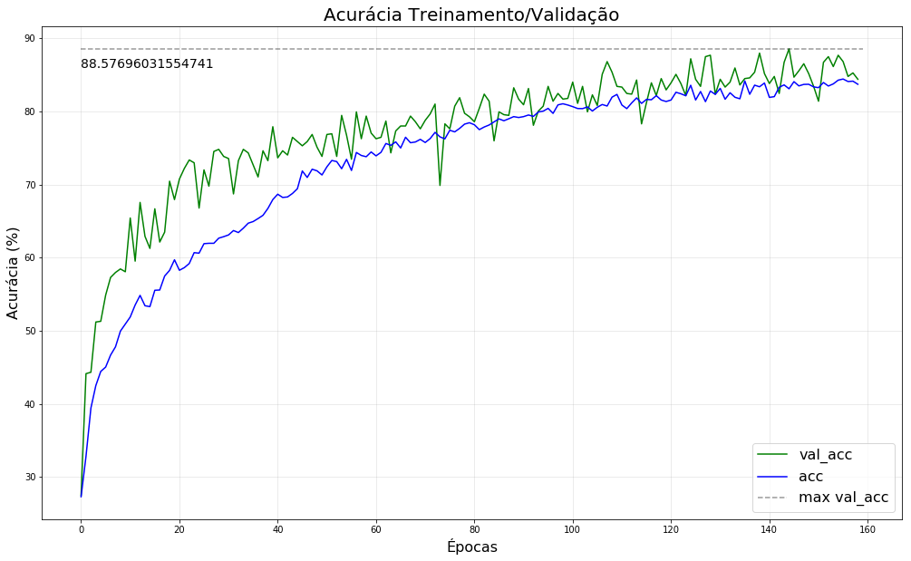

```python
loss, val_loss = np.array(history['loss']), np.array(history['val_loss'])
acc, val_acc = np.array(history['acc']), np.array(history['val_acc'])

fig, ax = plt.subplots(1, 1, figsize=(17, 10))

ax.plot(val_acc*100, label='val_acc', color='green')
ax.plot(acc*100, label='acc', color='blue')
ax.plot([0, len(val_acc)], [np.max(val_acc*100), np.max(val_acc*100)],
           color='k', linestyle='--', alpha=.4, label='max val_acc')
ax.text(0, 86, np.max(val_acc)*100, alpha=1, fontdict=dict(size=14))
ax.legend(fontsize=16)
ax.grid(alpha=.3)
ax.set_title('Acurácia Treinamento/Validação', fontdict=dict(size=20))
ax.set_xlabel('Épocas', fontdict=dict(size=16))
ax.set_ylabel('Acurácia (%)', fontdict=dict(size=16))

plt.savefig('results/accuracy_model_PT.png', dpi=100, bbox_inches='tight', transparent="False", pad_inches=0.1)
```

Abaixo é mostrado o gráfico com as informações da função de perda (*Categorical cross entropy*) durante o treinamento da rede.

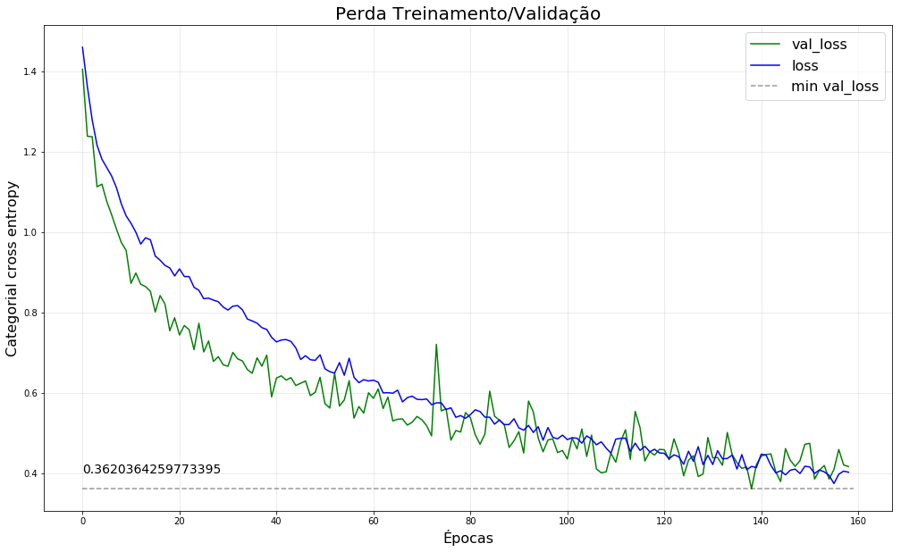

```python
loss, val_loss = np.array(history['loss']), np.array(history['val_loss'])
acc, val_acc = np.array(history['acc']), np.array(history['val_acc'])

fig, ax = plt.subplots(1, 1, figsize=(17, 10))

ax.plot(val_loss, label='val_loss', color='green')
ax.plot(loss, label='loss', color='blue')
ax.plot([0, len(val_loss)], [np.min(val_loss), np.min(val_loss)],
           color='k', linestyle='--', alpha=.4, label='min val_loss')
ax.text(0, 0.4, np.min(val_loss), alpha=1, fontdict=dict(size=14))
ax.legend(fontsize=16)
ax.grid(alpha=.3)
ax.set_title('Perda Treinamento/Validação', fontdict=dict(size=20))
ax.set_xlabel('Épocas', fontdict=dict(size=16))
ax.set_ylabel('Categorial cross entropy', fontdict=dict(size=16))

plt.savefig('results/loss_model_PT.png', dpi=100, bbox_inches='tight', transparent="False", pad_inches=0.1)
```

A célula abaixo realiza classificação das imagens de acordo com sua intensidade de temperatura e adiciona o reslutado em uma matriz de confusão.

```python
pred = model.predict(X).argmax(axis=1)
cm = confusion_matrix(y, pred)
```

A célula abaixo exibe o gráfico da métrica de matriz de confusão em relação às classificações realizadas pelo modelo.

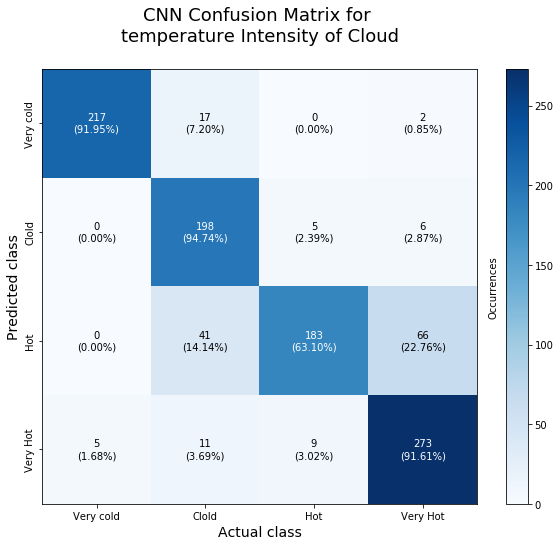

```python
figsize = (15, 8)
fig, ax = plt.subplots(1, 1, figsize=figsize)

cmap = plt.cm.Blues
divider = make_axes_locatable(ax)
cax = divider.append_axes("right", size="5%", pad=0.4)

total_samples = cm.sum(axis=1)[:, np.newaxis]
normed_conf_mat = cm.astype('float') / total_samples
labels = ['Very cold', 'Clold', 'Hot', 'Very Hot']
label_font = dict(fontweight='normal', size=14)
title_font = dict(fontweight='normal', size=18)

matshow = ax.matshow(cm, cmap=cmap)
cb = plt.colorbar(matshow, cax=cax, orientation='vertical')

for i in range(cm.shape[0]):
    for j in range(cm.shape[1]):
        cell_text = str(cm[i, j])
        cell_text += '\n(%.2f%%)' % (normed_conf_mat[i, j] * 100)
        ax.text(x=j,
                y=i,
                s=cell_text,
                va='center',
                ha='center',
                color="white" if normed_conf_mat[i, j] > 0.5 else "black")

ax.set_xticklabels([''] + labels)
ax.set_yticklabels([''] + labels, rotation=90, va='center')
ax.yaxis.set_ticks_position('left')
ax.xaxis.set_ticks_position('bottom')

#     ax.set_title('Matriz de confusão para %d testes'%((n*2)*0.2), fontdict=title_font)
ax.set_xlabel('Actual class', fontdict=label_font)
ax.set_ylabel('Predicted class', fontdict=label_font)
cb.ax.set_ylabel('Occurrences', va='center', rotation=-270, labelpad=-60)
ax.set_title('CNN Confusion Matrix for \ntemperature Intensity of Cloud', fontdict=title_font)

plt.savefig('results/confusion_matrix_blue.png', dpi=300, \
           bbox_inches='tight', transparent="False", pad_inches=0.1)
plt.show()
```

A fim de mostrar a relação entre as classes observadas e previstas para cada um dos estados, foi criado o gráfico de barrras. A célula abaixo tem o trecho de código responsável pela aplicação do modelo para realizar as previsões das classes e guardá-las em um dicionário assim como as classes observadas.

```python
ypred = model.predict(X).argmax(axis=1)

ans_pred = {}
ans_test = {}

for i, row in df_test.iterrows():
    state = row['image_path'].split('/')[2]
    class_ = row['class']
    if not ans_test.get(state):
        ans_test[state] = {1: 0, 2: 0, 3: 0, 4: 0}
        ans_pred[state] = {1: 0, 2: 0, 3: 0, 4: 0}
    ans_test[state][class_] += 1
    ans_pred[state][ypred[i]] += 1
```

O código da célula tem como finalidade prepara e exibir o gráfico de barra com as relações entre o total de ocorrência em cada estado para as classes observadas e previstas.

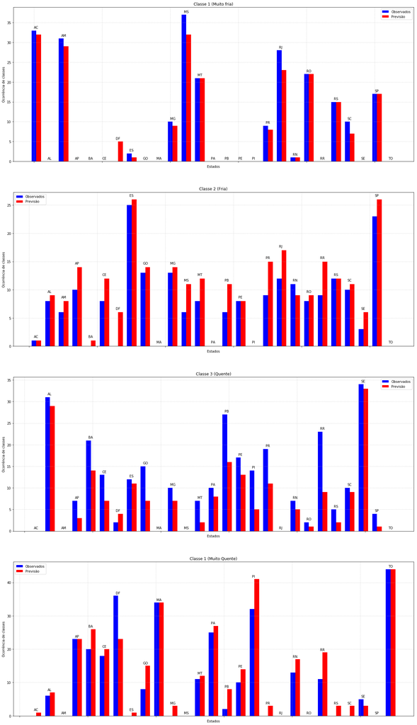

```python
fig, ax = plt.subplots(4, 1, figsize=(22, 40))
width = 0.35
labels = np.arange(len(ans_test.keys())).astype(float)
titles = ['Classe 1 (Muito fria)', 'Classe 2 (Fria)', 'Classe 3 (Quente)', 'Classe 1 (Muito Quente)']
for c, title in zip(np.arange(1, 5), titles):
    values = [ans_test[key][c] for key in sorted(ans_test.keys())]
    ax[c-1].bar(labels, values, width=width, color='b', label='Observados')

    labels += width
    values = [ans_pred[key][c] for key in sorted(ans_pred.keys())]
    ax[c-1].bar(labels, values, width=width, color='r', label='Previsão')

    for i, key in enumerate(sorted(ans_test.keys())):
        ax[c-1].text(labels[i]-width, max(ans_test[key][c], ans_pred[key][c])+0.5, key)
    ax[c-1].set_xticklabels([])
    ax[c-1].set_xlabel('Estados')
    ax[c-1].set_ylabel('Ocorrência de classes')
    ax[c-1].legend()
    ax[c-1].set_title(title)
    ax[c-1].grid(alpha=.5, linestyle='--')
```

A fim de verificar a relação entre as intensidades das temperaturas dos topos das nuvens e a severidade, foram carregados os dados do produto *flash* computado pelo instrumento GLM (*Geostationary Lightning Mapper*). Este produto é gerado a partir de um certo limiar de energia que é radiado, e então agrupado por um algoritmo (LCFA - *Lightning Cluster-Filter Algorithm* ) desenvolvido pela NOAA (*National Oceanic and Atmospheric Administration*). Este produto representa as coordenadas da ocorrência de raios, uma das principais características de severidade em tempestades.

```python
df = pd.read_csv("time_serie_lightning.csv").iloc[:, 1:]
df.head()
```

|  | ACRE | ALAGOAS | AMAZONAS | AMAPA | BAHIA | CEARA | DISTRITO FEDERAL | ESPIRITO SANTO | GOIAS | MARANHAO | ... | PARANA | RIO DE JANEIRO | RIO GRANDE DO NORTE | RONDONIA | RORAIMA | RIO GRANDE DO SUL | SANTA CATARINA | SERGIPE | SAO PAULO | TOCANTINS |
| --- | --- | --- | --- | --- | --- | --- | --- | --- | --- | --- | --- | --- | --- | --- | --- | --- | --- | --- | --- | --- | --- |
| 0 | 0.0 | 0.0 | 208.0 | 0.0 | 290.0 | 0.0 | 0.0 | 0.0 | 29.0 | 3.0 | ... | 89.0 | 0.0 | 0.0 | 0.0 | 1.0 | 0.0 | 0.0 | 0.0 | 43.0 | 1090.0 |
| 1 | 0.0 | 0.0 | 204.0 | 0.0 | 247.0 | 0.0 | 0.0 | 0.0 | 46.0 | 21.0 | ... | 108.0 | 0.0 | 0.0 | 0.0 | 0.0 | 0.0 | 0.0 | 0.0 | 36.0 | 1212.0 |
| 2 | 1.0 | 0.0 | 176.0 | 0.0 | 230.0 | 0.0 | 0.0 | 0.0 | 51.0 | 22.0 | ... | 112.0 | 0.0 | 0.0 | 0.0 | 0.0 | 0.0 | 0.0 | 0.0 | 34.0 | 1167.0 |
| 3 | 0.0 | 0.0 | 126.0 | 0.0 | 223.0 | 0.0 | 0.0 | 0.0 | 62.0 | 30.0 | ... | 130.0 | 0.0 | 0.0 | 0.0 | 0.0 | 0.0 | 0.0 | 0.0 | 34.0 | 1116.0 |
| 4 | 0.0 | 0.0 | 92.0 | 0.0 | 234.0 | 0.0 | 0.0 | 0.0 | 55.0 | 26.0 | ... | 114.0 | 0.0 | 0.0 | 0.0 | 2.0 | 0.0 | 1.0 | 0.0 | 16.0 | 1125.0 |

5 rows × 27 columns

```
Text(0,0.5,'Total de flashs')
```

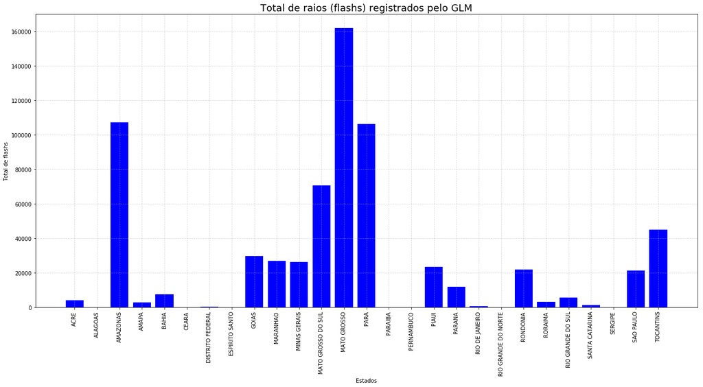

```python
sl = list(df.sum().astype(int).index)
sv = list(df.sum().astype(int).values)

plt.figure(figsize=(22, 10))
plt.bar(sl, sv, color='b')
_ = plt.xticks(rotation=90)
plt.grid(alpha=.5, linestyle='--')
plt.title('Total de raios (flashs) registrados pelo GLM', fontdict=dict(fontsize=18))
plt.xlabel('Estados')
plt.ylabel('Total de flashs')
```

## Referências

Chinchay, J. H. H. (2018). Uso de multi-canais do goes-16 para previsão imediata de densidade de descargas elétricas. Dissertação de mestrado, Instituto Nacional de Pesquisas Espaciais (INPE).

Goodman, S. J., Blakeslee, R. J., Koshak, W. J., Mach, D., Bailey, J., Buechler, D., Carey, L., Schultz, C., Bateman, M., McCaul Jr, E., et al. (2013). The goes-r geostationary lightning mapper (glm). Atmospheric research, 125:34–49.

Houze, J. and Robert, A. (2004). Mesoscale convective systems. Reviews of Geophysics, 42(4).

Hubel, D. and Wiesel, T. (1968). Receptive fields and functional architecture of monkey striate cortex. Journal of Physiology (London), 195, 215–243.

Kohonen, T. (1982). Self-organized formation of topologically correct feature maps. Biological Cybernetics, 43.

Nunes, L. H. (1998). A escala nas ciências atmosféricas. Revista do Instituto Geologico, 19(1-2):71–73.

Orlanski, I. (1975). A rational subdivision of scales for atmospheric processes. Bulletin of the American Meteorological Society, pages 527–530.